# ggplot

## Histograms

Just use an “x” aesthetic, not x and y:

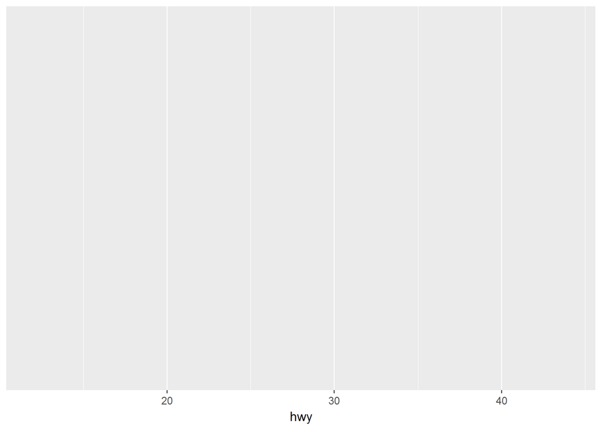

```r
ggplot(mpg, aes(hwy))
```

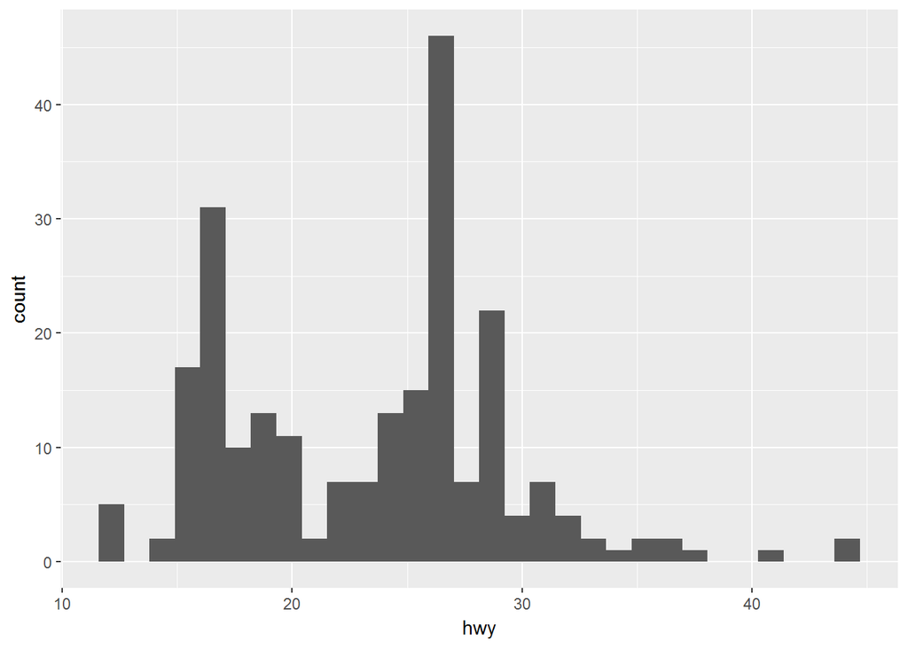

```r
ggplot(mpg, aes(hwy)) + geom_histogram()
```

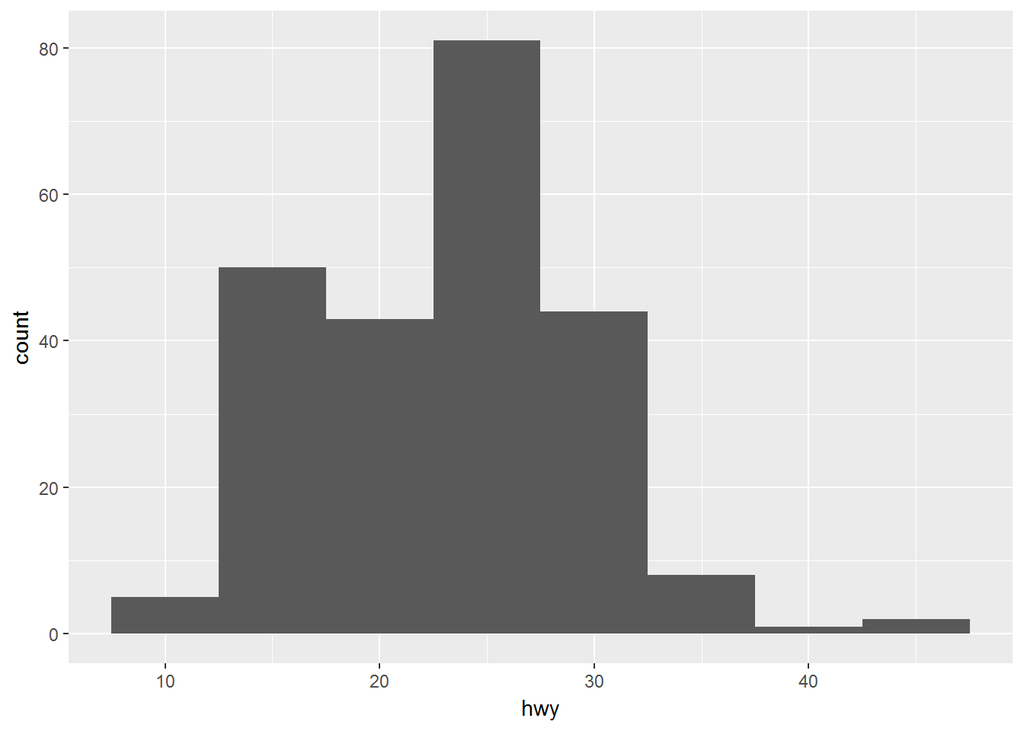

```r
ggplot(mpg, aes(hwy)) + geom_histogram(binwidth = 5)
```

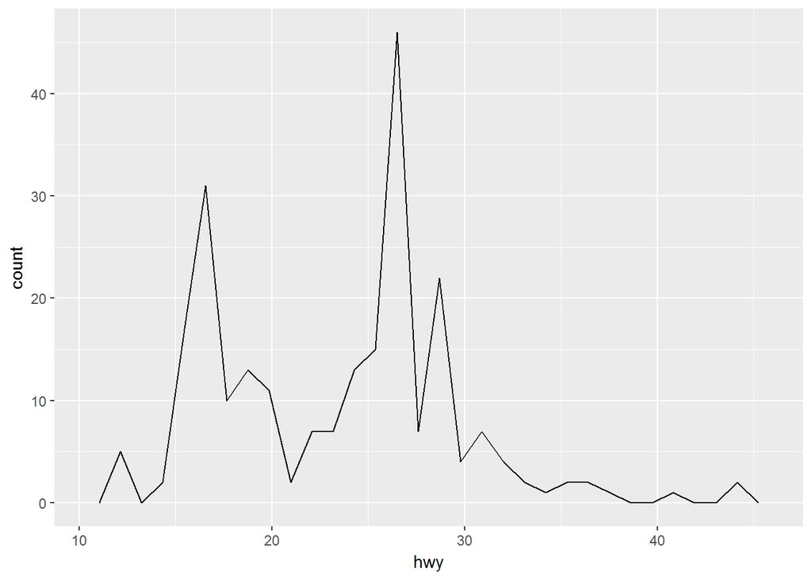

```r
ggplot(mpg, aes(hwy)) + geom_freqpoly()
```

Subsetting by drv:

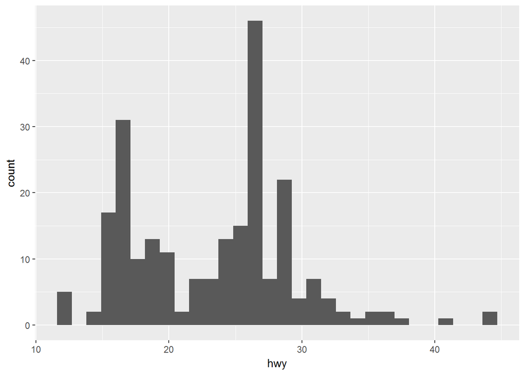

```r
p <- ggplot(mpg, aes(x = hwy))
p + geom_histogram()
```

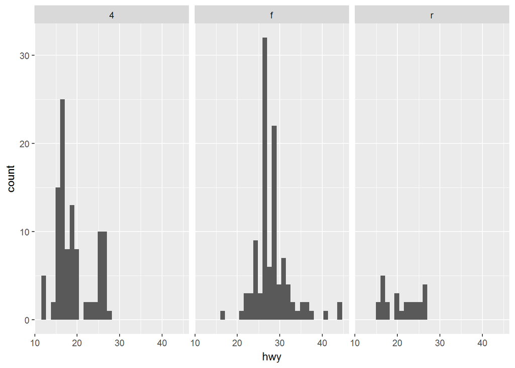

```r
p + geom_histogram() + facet_wrap(~drv)
```

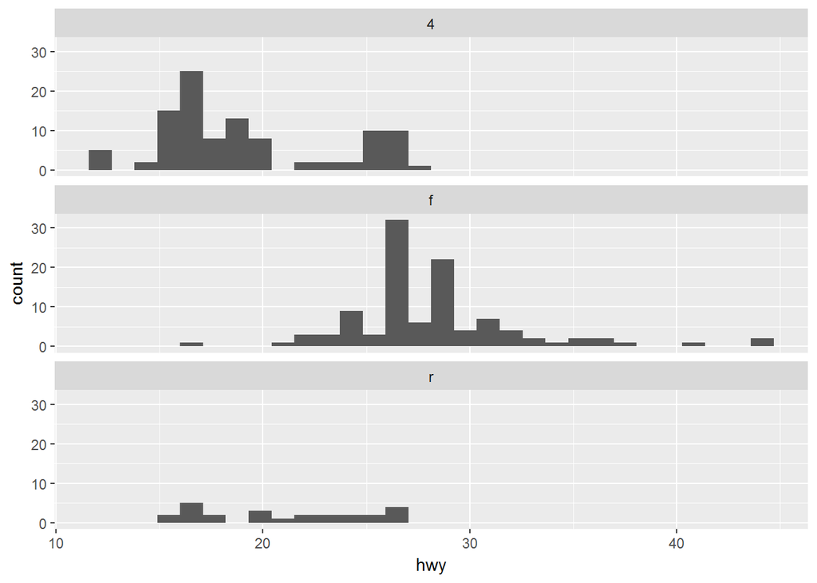

```r
p + geom_histogram() + facet_wrap(~drv, ncol = 1)
```

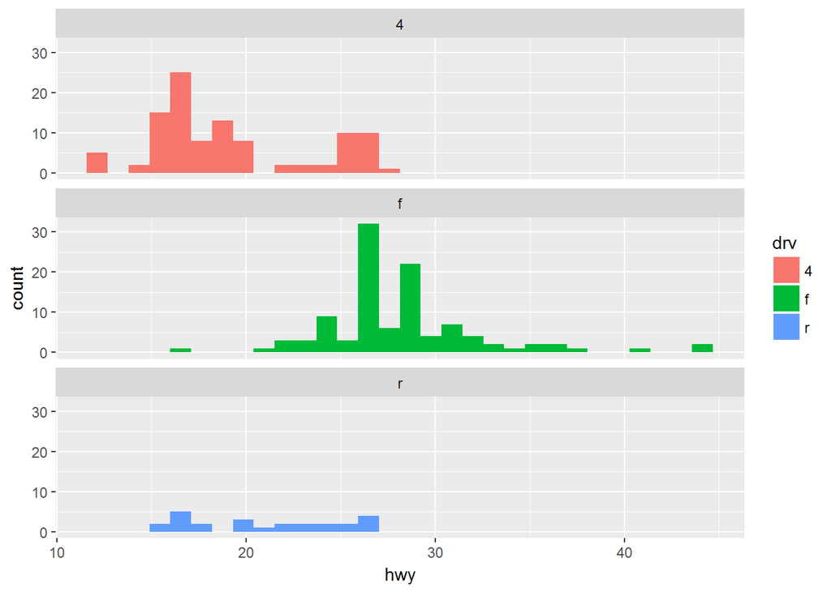

```r
p + geom_histogram(aes(fill=drv)) + facet_wrap(~drv, ncol = 1)
```

A couple more things thrown in for fun (didn’t get to see these in class):

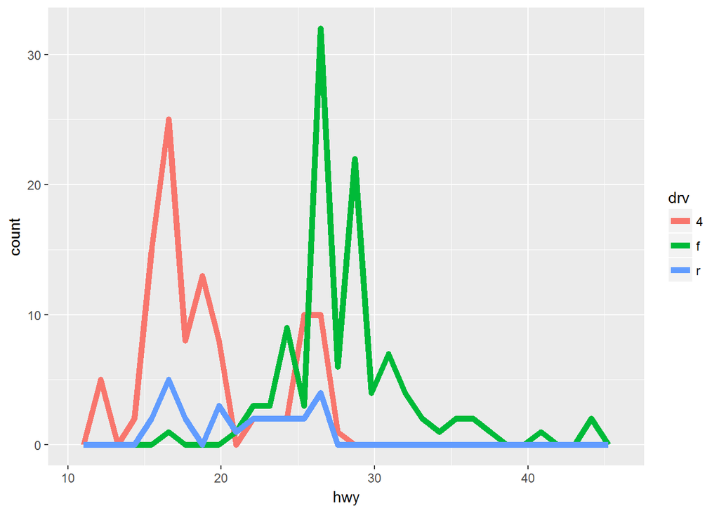

```r
p + aes(color=drv) + geom_freqpoly(lwd=2)
```

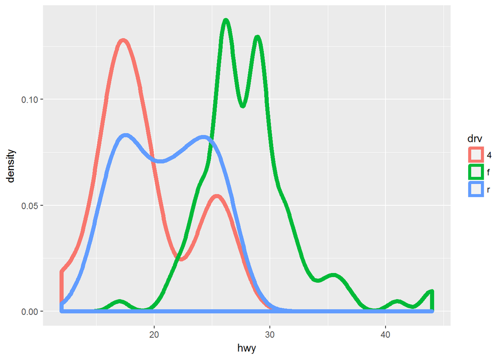

```r
p + aes(color=drv) + geom_density(lwd=2)
```

## Titles and axis labels

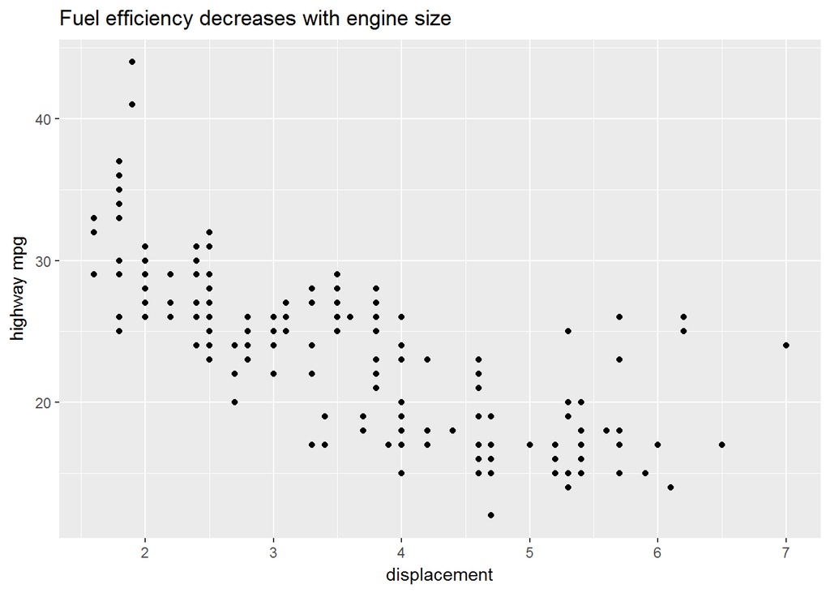

```r
# See cheatsheet, p. 2, "Labels" section.
ggplot(mpg, aes(displ, hwy)) + geom_point() + labs(x="displacement", y="highway mpg", title="Fuel efficiency decreases with engine size")
```

## Back to college data and first-generation percentages

```r
source(file = "http://www.stat.yale.edu/~jtc5/STAT230/data/170309-college-dump.r")
colleges
```

```
## [1] "Yale University"
## [2] "Harvard University"
## [3] "Princeton University"
## [4] "University of Connecticut"
## [5] "University of Massachusetts-Amherst"
## [6] "Rutgers University-New Brunswick"
```

```r
r
```

```
## # A tibble: 60 × 3
##     firstgen         college  year
##        <dbl>           <chr> <int>
## 1  0.1430281 Yale University  2005
## 2  0.1476378 Yale University  2006
## 3  0.1610787 Yale University  2007
## 4  0.1844106 Yale University  2008
## 5  0.2078804 Yale University  2009
## 6  0.1866667 Yale University  2010
## 7  0.1857335 Yale University  2011
## 8  0.2054208 Yale University  2012
## 9  0.2009132 Yale University  2013
## 10 0.2246256 Yale University  2014
## # ... with 50 more rows
```

The plot we did last time:

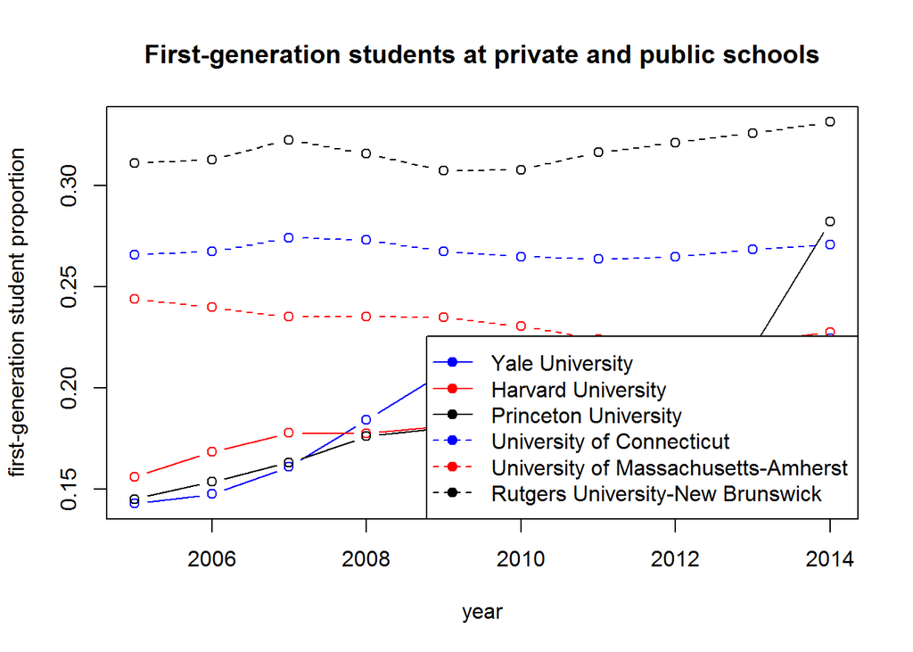

```r
colors <- c("blue", "red", "black", "blue", "red", "black")
types <- c(1,1,1,2,2,2)
plot(firstgen ~ year, data=r, type="n", ylab="first-generation student proportion")
for(i in 1:length(colleges)){
  rows <- which(r$college == colleges[i])
  lines(r$year[rows], r$firstgen[rows], type="b", lty=types[i], col=colors[i])
}
#
# Looks ok up to here.  Let's add a legend:
#
legend("bottomright", legend=colleges, col=colors, lty=types, pch=19) # cex=0.65
title(main="First-generation students at private and public schools")
```

Here is a way to make a similar plot using ggplot, again putting the legends outside the coordinate axes where they belong.

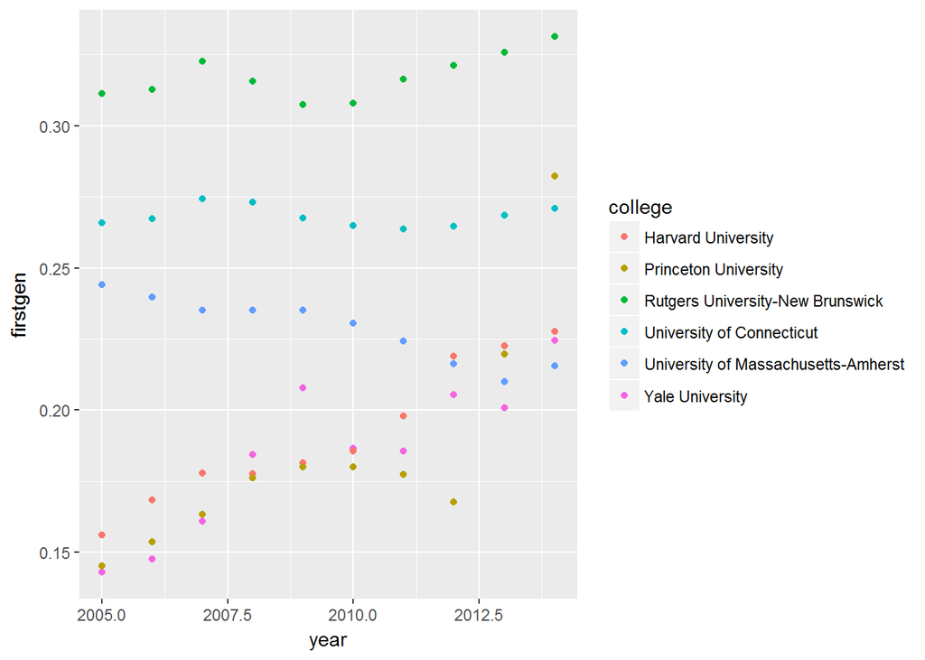

```r
# View(r)
r$type <- rep(c("private","public"), each=30)

ggplot(r, aes(x = year, y=firstgen, color=college)) +
  geom_point()
```

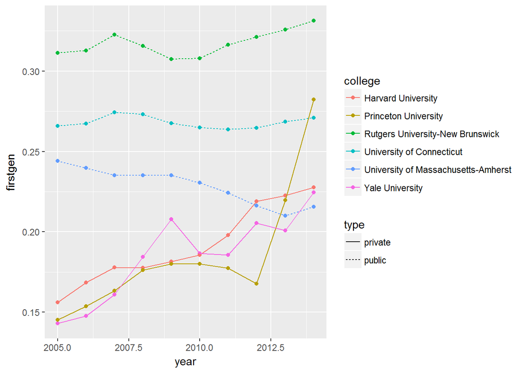

```r
ggplot(r, aes(x = year, y=firstgen, color=college, linetype=type)) +
  geom_point() + geom_line()
```

That looks quite good to me, and it’s easy too!

Oops, just noticed the years like 2007.5, which doesn’t seem so nice. We can modify the x axis scale with scale_x_continuous:

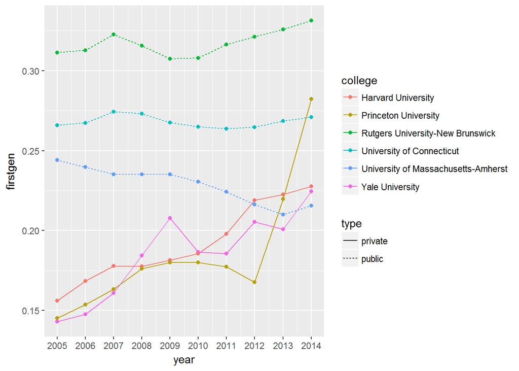

```r
ggplot(r, aes(x = year, y=firstgen, color=college, linetype=type)) +
  geom_point() + geom_line() +
  scale_x_continuous(breaks = 2005:2014)
```

That’s nice. We don’t need the grid lines between the “major” grid lines, so here is a way to remove them:

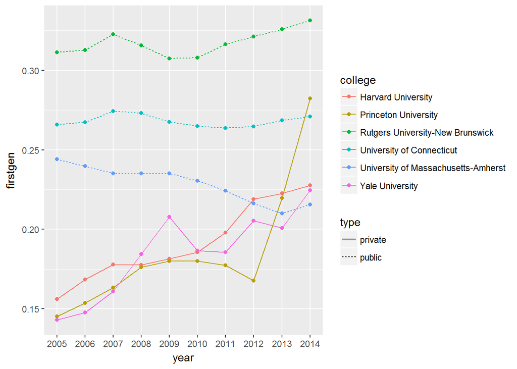

```r
ggplot(r, aes(x = year, y=firstgen, color=college, linetype=type)) +
  geom_point() + geom_line() +
  scale_x_continuous(breaks = 2005:2014, minor_breaks = NULL)
```

Oh, and I forgot a title:

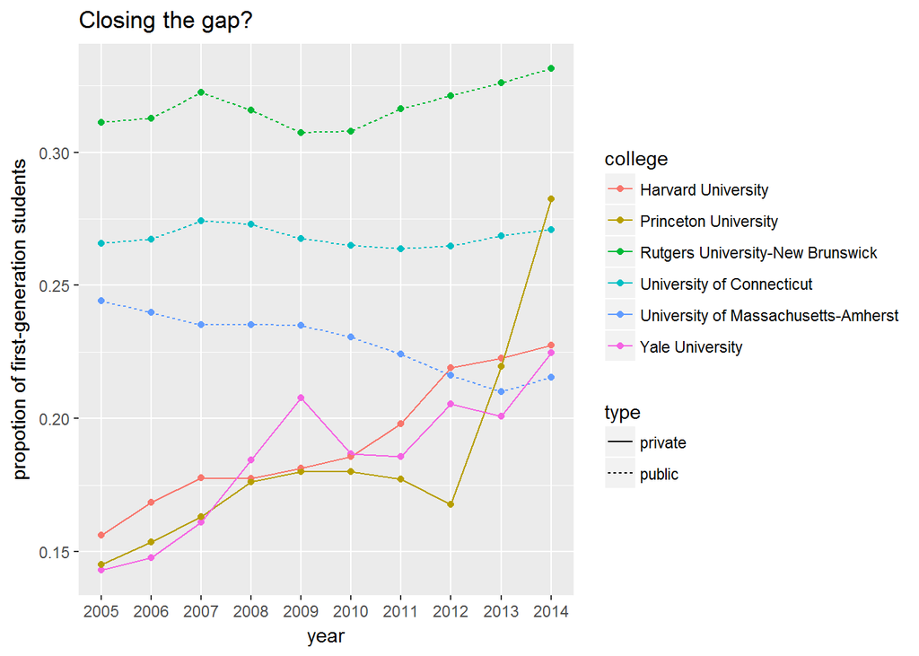

```r
ggplot(r, aes(x = year, y=firstgen, color=college, linetype=type)) +
  geom_point() + geom_line() +
  scale_x_continuous(breaks = 2005:2014, minor_breaks = NULL) +
  labs(title="Closing the gap?",
       y="propotion of first-generation students")
```